# Wulfing_HW02

Sophie Wulfing

2/12/2022

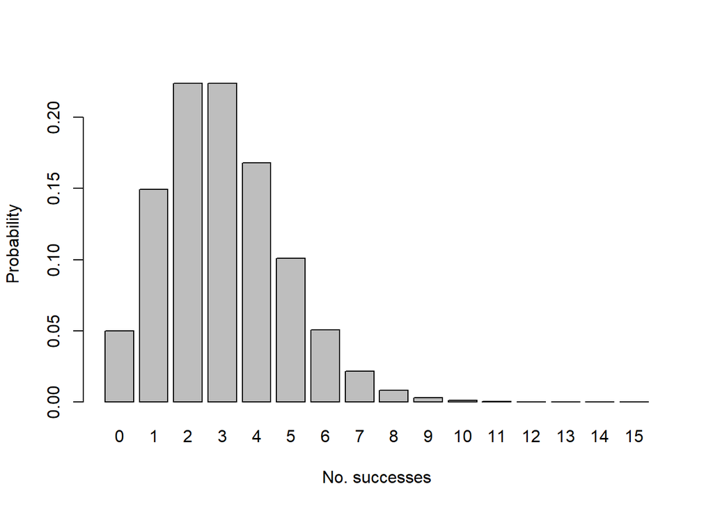

```r
p <- dpois(x = 0:15, lambda = 3)

barplot(p, names.arg = 0:15,
        xlab = "No. successes",
        ylab = "Probability")
```

**3. Prove that the mean of a gamma distribution is the shape divided by the rate by simulating data with a known shape and rate and taking the mean of those simulated data. (For this exercise, just provide the R code – no need to write an answer). If you’d like to, show this visually using a histogram that depicts the simulated data and includes a vertical line representing the true mean as solid black line and another vertical line representing the mean of your simulated data as a dashed red line.**

```r
shape = 1.5
rate = 0.1
 y <- rgamma(1000, shape, rate)
mean(y)
```

```
## [1] 15.12688
```

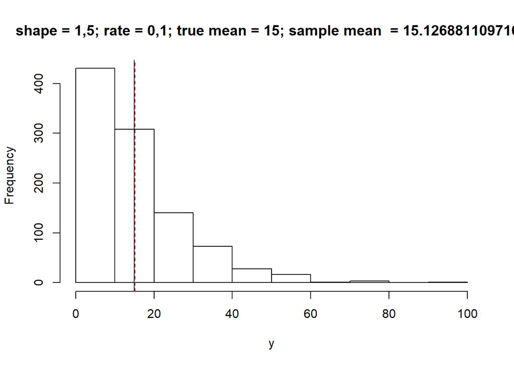

```r
hist(y,
       main = paste("shape = 1,5; rate = 0,1; true mean = ", shape/rate,
                    "; sample mean  = ", mean(y),sep = ""))
abline(v = mean(y), col = "red", lty = 2)
abline(v = shape/rate)
```

**4. Suppose you have 20 sample plots and are searching for moose using drones. You searcheach plot once. If the probability of detecting at least one moose in a plot (a “success”) during a given search is 0.17, what is the probability that you detect at least one moose in exactly 5 out of the 20 plots?** probability = 0.1345426 (see code)

```r
dbinom(x = 5,
       size = 20,
       prob = .17)
```

```
## [1] 0.1345426
```

**5. Describe in your own words the relationship between likelihood, probability, and a maximum likelihood estimate.**